# Deep Learning- 課程 11－Deep Learning- Using Pre-trained model - Image Classification - Python Tutorial

''' 人工智慧- 進階課程 A.I Tutorials - Advanced Course - Deep Learning 教程 ''' 05 - 深度學習 教程 課程 11－Deep Learning- Using Pre-trained model - Image Classification - Keras 預訓練模型-圖像分類 程式範例 - Keras 預訓練模型- 圖像分類 ''' ''' >> 資料準備 >> 你我互動學習園地- 進階課程 Advanced Course >> https://interactiveuandmetutorialsac.weebly.com/ >> 你我互動學習園地 >> https://interactiveuandmetutorials.weebly.com/ >> Python 程式語言 設計 >> https://pythonprogrammingtutorials.weebly.com/ >> 目錄結構 : >> Deep Learning- 課程 10- Deep Learning- Pre-trained model - Image classification .zip 檔案路徑/ ├── 課程 10 - Pre-trained model - Image classification.ipynb └── images/ ├── dog.jpg ├── peson.jpg └── biking.jpg ''' ''' - Keras >> https://keras.io/ '''

''' - ImageNet 影像網 - 圖像分類 - 為1,000種 不同的類別 - from keras.applications.vgg16 import VGG16 - model = VGG16() >> http://www.image-net.org/ '''

```python
ddir
```

# 程式範例

## Import 相關函式庫

```python
import platform
```

```python
!python -V
platform.python_version()
```

```
Python 3.7.3
```

```
'3.7.3'
```

```python
import tensorflow
import keras
print("Platform: {}".format(platform.platform()))
print("Tensorflow version: {}".format(tensorflow.__version__))
print("Keras version: {}".format(keras.__version__))
```

```
Platform: Windows-10-10.0.18362-SP0
Tensorflow version: 1.14.0
Keras version: 2.2.4
```

```python
%matplotlib inline
import matplotlib.pyplot as plt
import matplotlib.image as mpimg
import numpy as np
from IPython.display import Image
```

- Install plot_model/ Image
  - pip install graphviz
  - pip install pydot

# VGG16

'''''' >> 獲取圖像 '''''' - 加載 LOADING - VGG 模型 - 加載 Keras - 己經 - 預訓練好的 VGG-16 - 權重模型 檔 ''''

```python
%%time

from keras.applications.vgg16 import VGG16

# 載入權重

model_vgg16 = VGG16()
```

```
Wall time: 3.17 s
```

```python
import pydot
from IPython.display import Image
from keras.utils import plot_model
```

```python
model_vgg16.summary()
plot_model(model_vgg16, to_file='vgg16model.png')
```

```
_________________________________________________________________
Layer (type)                 Output Shape              Param #
=================================================================
input_3 (InputLayer)         (None, 224, 224, 3)       0
_________________________________________________________________
block1_conv1 (Conv2D)        (None, 224, 224, 64)      1792
_________________________________________________________________
block1_conv2 (Conv2D)        (None, 224, 224, 64)      36928
_________________________________________________________________
block1_pool (MaxPooling2D)   (None, 112, 112, 64)      0
_________________________________________________________________
block2_conv1 (Conv2D)        (None, 112, 112, 128)     73856
_________________________________________________________________
block2_conv2 (Conv2D)        (None, 112, 112, 128)     147584
_________________________________________________________________
block2_pool (MaxPooling2D)   (None, 56, 56, 128)       0
_________________________________________________________________
block3_conv1 (Conv2D)        (None, 56, 56, 256)       295168
_________________________________________________________________
block3_conv2 (Conv2D)        (None, 56, 56, 256)       590080
_________________________________________________________________
block3_conv3 (Conv2D)        (None, 56, 56, 256)       590080
_________________________________________________________________
block3_pool (MaxPooling2D)   (None, 28, 28, 256)       0
_________________________________________________________________
block4_conv1 (Conv2D)        (None, 28, 28, 512)       1180160
_________________________________________________________________
block4_conv2 (Conv2D)        (None, 28, 28, 512)       2359808
_________________________________________________________________
block4_conv3 (Conv2D)        (None, 28, 28, 512)       2359808
_________________________________________________________________
block4_pool (MaxPooling2D)   (None, 14, 14, 512)       0
_________________________________________________________________
block5_conv1 (Conv2D)        (None, 14, 14, 512)       2359808
_________________________________________________________________
block5_conv2 (Conv2D)        (None, 14, 14, 512)       2359808
_________________________________________________________________
block5_conv3 (Conv2D)        (None, 14, 14, 512)       2359808
_________________________________________________________________
block5_pool (MaxPooling2D)   (None, 7, 7, 512)         0
_________________________________________________________________
flatten (Flatten)            (None, 25088)             0
_________________________________________________________________
fc1 (Dense)                  (None, 4096)              102764544
_________________________________________________________________
fc2 (Dense)                  (None, 4096)              16781312
_________________________________________________________________
predictions (Dense)          (None, 1000)              4097000
=================================================================
Total params: 138,357,544
Trainable params: 138,357,544
Non-trainable params: 0
_________________________________________________________________
```

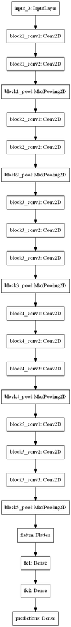

```python
Image('vgg16model.png')
```

''' - 加載 / 準備 圖像 Image - 轉換 預訓練網絡 - 所要求 - 張量 - Keras 提供了工具 - load_img() 函數 - 加載 圖像 - resize 大小調整 - 224 × 224 像素 '''

```python
import cv2
cv2.__version__
```

```
'4.1.0'
```

''' >> 查看原始照片 - Review Orginal Phote '''

```python
%matplotlib inline
import cv2
import numpy as np
import matplotlib.pyplot as plt
```

```
(576, 768, 3)
```

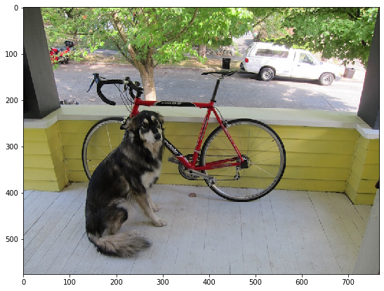

```python
img = cv2.imread('images/dog.jpg')
img = cv2.cvtColor(img, cv2.COLOR_BGR2RGB)
plt.figure(figsize = (20, 20))
plt.subplot(1, 2, 1); plt.imshow(img)
img.shape
```

```
images/dog.jpg
```

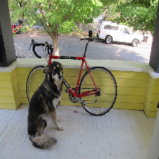

```python
from keras.preprocessing.image import load_img
import numpy as np

# 載入圖像檔
img_file = 'images/dog.jpg'

#  VGG1模型的輸入 - 224x224
image = load_img(img_file, target_size=(224, 224))
print(img_file)
image
```

''' - 像素轉換 - NumPy 數組 - img_to_array()函數 '''

```python
from keras.preprocessing.image import img_to_array

# 將圖像資料轉為 numpy array

image = img_to_array(image) # RGB

print("image.shape:", image.shape)
```

```
image.shape: (224, 224, 3)
```

```python
image.dtype,image.shape
```

```
(dtype('float32'), (224, 224, 3))
```

''' - VGG16 網絡 - 單色階 (Grey) / 多色階圖像 (RGB) - 作為輸入 - 輸入數組 - 轉換成 - 四個維度 - 圖像批次量，圖像高，圖像寬, 圖像色階數 - batch_size, img_height, img_width, img_channels - 只有一個樣本（一個圖像） - 通過 reshape() - 重新調整 - 數組的形狀 Array Shape - 並添加額外的維度 '''

```python
# 調整 張量 - 的維度

image = image.reshape((1, image.shape[0], image.shape[1], image.shape[2]))

print("image.shape:", image.shape)
```

```
image.shape: (1, 224, 224, 3)
```

```python
image.dtype,image.shape
```

```
(dtype('float32'), (1, 224, 224, 3))
```

''' - 按照 VGG 在訓練 ImageNet數據 一樣的方法 - 對圖像進行前處理 - 論文裡談到： - The only preprocessing we do is subtracting the mean RGB value, computed on the training set, from each pixel. - Very Deep Convolutional Networks for Large-Scale Image Recognition, 2014.__ - Keras - preprocess_input() 函數 - VGG 網絡 - 新的圖像 輸入 '''

```python
from keras.applications.vgg16 import preprocess_input

# 準備 VGG 模型  - 圖像

image = preprocess_input(image)
```

```python
image.shape,image.dtype
```

```
((1, 224, 224, 3), dtype('float32'))
```

''' - 預測 - 模型中 - predict()函數 - 預測圖像 - 屬於 1000個 - 對像 Class 類型 - 的機率 '''

```python
# 預測 - 所有產出類別 - 的機率

y_pred = model_vgg16.predict(image)
print(len(max(y_pred)))
```

```
1000
```

''' - 解釋預測 - Keras 提供一個 函數 - decode_predictions() 的 概率 - 返回 - 一個類別 - 的 列表 - 每一個類別 - 的 機率 - 第一個 機率最高 - 的 種類 '''

```python
from keras.applications.vgg16 import decode_predictions

# 機率轉換 - 為類別標籤

label = decode_predictions(y_pred)

# 檢索最可能的結果- 例如最高的概率

label = label[0][0]

# 顯示 預測 結果 - Malamute 愛斯基摩 狗

print('%s (%.2f%%)' % (label[1], label[2]*100))
```

```
Downloading data from https://storage.googleapis.com/download.tensorflow.org/data/imagenet_class_index.json
malamute (32.37%)
```

```python
print(label)
print(label[1][1])
```

```
('n02110063', 'malamute', 0.3237261)
a
```

```python
# 顯示 預測 結果

print('%s (%.2f%%)' % (label[1], label[2]*100))
```

```
malamute (32.37%)
```

```python
# 顯示- 網絡結構
model_vgg16.summary()

# plot graph
plot_model(model_vgg16, to_file='vgg16model.png')
```

```
_________________________________________________________________
Layer (type)                 Output Shape              Param #
=================================================================
input_3 (InputLayer)         (None, 224, 224, 3)       0
_________________________________________________________________
block1_conv1 (Conv2D)        (None, 224, 224, 64)      1792
_________________________________________________________________
block1_conv2 (Conv2D)        (None, 224, 224, 64)      36928
_________________________________________________________________
block1_pool (MaxPooling2D)   (None, 112, 112, 64)      0
_________________________________________________________________
block2_conv1 (Conv2D)        (None, 112, 112, 128)     73856
_________________________________________________________________
block2_conv2 (Conv2D)        (None, 112, 112, 128)     147584
_________________________________________________________________
block2_pool (MaxPooling2D)   (None, 56, 56, 128)       0
_________________________________________________________________
block3_conv1 (Conv2D)        (None, 56, 56, 256)       295168
_________________________________________________________________
block3_conv2 (Conv2D)        (None, 56, 56, 256)       590080
_________________________________________________________________
block3_conv3 (Conv2D)        (None, 56, 56, 256)       590080
_________________________________________________________________
block3_pool (MaxPooling2D)   (None, 28, 28, 256)       0
_________________________________________________________________
block4_conv1 (Conv2D)        (None, 28, 28, 512)       1180160
_________________________________________________________________
block4_conv2 (Conv2D)        (None, 28, 28, 512)       2359808
_________________________________________________________________
block4_conv3 (Conv2D)        (None, 28, 28, 512)       2359808
_________________________________________________________________
block4_pool (MaxPooling2D)   (None, 14, 14, 512)       0
_________________________________________________________________
block5_conv1 (Conv2D)        (None, 14, 14, 512)       2359808
_________________________________________________________________
block5_conv2 (Conv2D)        (None, 14, 14, 512)       2359808
_________________________________________________________________
block5_conv3 (Conv2D)        (None, 14, 14, 512)       2359808
_________________________________________________________________
block5_pool (MaxPooling2D)   (None, 7, 7, 512)         0
_________________________________________________________________
flatten (Flatten)            (None, 25088)             0
_________________________________________________________________
fc1 (Dense)                  (None, 4096)              102764544
_________________________________________________________________
fc2 (Dense)                  (None, 4096)              16781312
_________________________________________________________________
predictions (Dense)          (None, 1000)              4097000
=================================================================
Total params: 138,357,544
Trainable params: 138,357,544
Non-trainable params: 0
_________________________________________________________________
```

# VGG19 Model

```python
%%time

from keras.applications.vgg19 import VGG19
from keras.preprocessing import image
from keras.preprocessing.image import load_img
from keras.applications.vgg19 import preprocess_input
from keras.applications.vgg19 import decode_predictions

# 載入權重

model_vgg19 = VGG19(weights='imagenet')

# 載入圖像檔

img_file = 'images/dog.jpg'

# VGG19的模型 - 輸入是 224 x 224

image = load_img(img_file, target_size=(224, 224))
#print("image.shape:", image.shape)

# 圖像資料 轉為 numpy array

image = img_to_array(image) # RGB
print("image.shape:", image.shape)

# 調整張量 的維度

image = image.reshape((1, image.shape[0], image.shape[1], image.shape[2]))
print("image.shape:", image.shape)

# 準備模型所需要的圖像 - 前處理

image = preprocess_input(image)

# 預測 所有產出類別 - 的機率
y_pred = model_vgg19.predict(image)

# 機率轉換 為 類別標籤
label = decode_predictions(y_pred)

# 檢索最可能的結果，例如最高的概率
label = label[0][0]

# 顯示預測 結果

print('%s (%.2f%%)' % (label[1], label[2]*100))
```

```
Downloading data from https://github.com/fchollet/deep-learning-models/releases/download/v0.1/vgg19_weights_tf_dim_ordering_tf_kernels.h5
image.shape: (224, 224, 3)
image.shape: (1, 224, 224, 3)
malamute (13.06%)
Wall time: 3min 15s
```

# ResNet50

```python
%%time

from keras.applications.resnet50 import ResNet50
from keras.preprocessing import image
from keras.preprocessing.image import load_img
from keras.applications.resnet50 import preprocess_input
from keras.applications.resnet50 import decode_predictions

# 載入權重
model_resnet50 = ResNet50(weights='imagenet')

# 載入圖像檔
img_file = 'images/dog.jpg'
#img_file = 'evimg16tf.jpg'

# ResNet 模型 的輸入 - 224x224
image = load_img(img_file, target_size=(224, 224))

# 將圖像資料轉為numpy array
image = img_to_array(image) # RGB
print("image.shape:", image.shape)

# 調整張量的維度
image = image.reshape((1, image.shape[0], image.shape[1], image.shape[2]))
print("image.shape:", image.shape)

# 準備模型所需要的圖像前處理
image = preprocess_input(image)

# 預測所有產出類別的機率
y_pred = model_resnet50.predict(image)

# 將機率轉換為類別標籤
label = decode_predictions(y_pred)

# 檢索最可能的結果，例如最高的概率
label = label[0][0]

# 顯示預測 結果
print('%s (%.2f%%)' % (label[1], label[2]*100))
```

```
W1113 16:46:21.396164 15556 deprecation_wrapper.py:119] From C:\Users\calvi\Anaconda3\lib\site-packages\keras\backend\tensorflow_backend.py:1834: The name tf.nn.fused_batch_norm is deprecated. Please use tf.compat.v1.nn.fused_batch_norm instead.
```

```
Downloading data from https://github.com/fchollet/deep-learning-models/releases/download/v0.2/resnet50_weights_tf_dim_ordering_tf_kernels.h5
image.shape: (224, 224, 3)
image.shape: (1, 224, 224, 3)
malamute (41.48%)
Wall time: 48.6 s
```

# InceptionV3

```python
%%time

from keras.applications.inception_v3 import InceptionV3
from keras.preprocessing import image
from keras.preprocessing.image import load_img
from keras.applications.inception_v3 import preprocess_input
from keras.applications.inception_v3 import decode_predictions

# 載入權重

model_inception_v3 = InceptionV3(weights='imagenet')

# 載入圖像檔

img_file = 'images/dog.jpg'

# InceptionV3的模型 的輸入 - 299 x 299

img = load_img(img_file, target_size=(299, 299))

# 將圖像資料轉為 numpy array

image = image.img_to_array(img) # RGB
print("image.shape:", image.shape)

# 調整張量的維度

image = image.reshape((1, image.shape[0], image.shape[1], image.shape[2]))
print("image.shape:", image.shape)

# 準備模型 - 所需要的圖像 - 前處理

image = preprocess_input(image)

# 預測所有產出類別的機率

y_pred = model_inception_v3.predict(image)

# 將機率轉換為類別標籤
label = decode_predictions(y_pred)

# 檢索最可能的結果，例如最高的概率

label = label[0][0]

# 顯示預測 結果

print('%s (%.2f%%)' % (label[1], label[2]*100))
```

```
W1113 16:50:53.690630 15556 deprecation_wrapper.py:119] From C:\Users\calvi\Anaconda3\lib\site-packages\keras\backend\tensorflow_backend.py:3980: The name tf.nn.avg_pool is deprecated. Please use tf.nn.avg_pool2d instead.
```

```
Downloading data from https://github.com/fchollet/deep-learning-models/releases/download/v0.5/inception_v3_weights_tf_dim_ordering_tf_kernels.h5
image.shape: (299, 299, 3)
image.shape: (1, 299, 299, 3)
malamute (83.50%)
Wall time: 46.2 s
```

# InceptionResNetV2

```python
%%time

from keras.applications.inception_resnet_v2 import InceptionResNetV2
from keras.preprocessing import image
from keras.preprocessing.image import load_img
from keras.applications.inception_resnet_v2 import preprocess_input
from keras.applications.inception_resnet_v2 import decode_predictions

# 載入權重

model_inception_resnet_v2 = InceptionResNetV2(weights='imagenet')

# 載入圖像檔

img_file = 'images/dog.jpg'
#img_file = 'evimg16tf.jpg'

# InceptionResNetV2 模型 - 的輸入是 299x299

image = load_img(img_file, target_size=(299, 299))

# 將圖像資料轉為numpy array

image = img_to_array(image) # RGB
print("image.shape:", image.shape)

# 調整張量的維度

image = image.reshape((1, image.shape[0], image.shape[1], image.shape[2]))
print("image.shape:", image.shape)

# 準備模型所需要的圖像前處理

image = preprocess_input(image)

# 預測所有產出類別的機率

y_pred = model_inception_resnet_v2.predict(image)

# 將機率轉換為類別標籤

label = decode_predictions(y_pred)

# 檢索最可能的結果，例如最高的概率

label = label[0][0]

# 顯示預測 結果

print('%s (%.2f%%)' % (label[1], label[2]*100))
```

```
Downloading data from https://github.com/fchollet/deep-learning-models/releases/download/v0.7/inception_resnet_v2_weights_tf_dim_ordering_tf_kernels.h5
image.shape: (299, 299, 3)
image.shape: (1, 299, 299, 3)
malamute (88.95%)
Wall time: 1min 30s
```